# Bases de R

# 6 Exploration des données

## 6.1 Examiner des données

- Examiner les premières ou dernières lignes

```r
head(InsectSprays)
```

|  | count | spray |
| --- | --- | --- |
| 1 | 10 | A |
| 2 | 7 | A |
| 3 | 20 | A |
| 4 | 14 | A |
| 5 | 14 | A |
| 6 | 12 | A |

```r
tail(InsectSprays, n=3)
```

|  | count | spray |
| --- | --- | --- |
| 70 | 26 | F |
| 71 | 24 | F |
| 72 | 13 | F |

- Résumé statistique

```r
summary(InsectSprays)
```

```
##      count       spray
##  Min.   : 0.00   A:12
##  1st Qu.: 3.00   B:12
##  Median : 7.00   C:12
##  Mean   : 9.50   D:12
##  3rd Qu.:14.25   E:12
##  Max.   :26.00   F:12
```

- Fonction `aggregate`

```r
aggregate(InsectSprays$count, by=list(InsectSprays$spray), FUN=mean)
```

| Group.1 | x |
| --- | --- |
| A | 14.500000 |
| B | 15.333333 |
| C | 2.083333 |
| D | 4.916667 |
| E | 3.500000 |
| F | 16.666667 |

```r
sumInsects <- aggregate(InsectSprays$count, by=list(InsectSprays$spray), FUN=sum)
names(sumInsects) <- c('group', 'sum')
print(sumInsects)
```

```
##   group sum
## 1     A 174
## 2     B 184
## 3     C  25
## 4     D  59
## 5     E  42
## 6     F 200
```

- Sous-ensembles avec critères

```r
warpbreaks[warpbreaks$wool=='A',]
```

|  | breaks | wool | tension |
| --- | --- | --- | --- |
| 1 | 26 | A | L |
| 2 | 30 | A | L |
| 3 | 54 | A | L |
| 4 | 25 | A | L |
| 5 | 70 | A | L |
| 6 | 52 | A | L |
| 7 | 51 | A | L |
| 8 | 26 | A | L |
| 9 | 67 | A | L |
| 10 | 18 | A | M |

[output cut: 17 more lines]

```r
warpbreaks[warpbreaks$tension %in% c('L','M'),]
```

|  | breaks | wool | tension |
| --- | --- | --- | --- |
| 1 | 26 | A | L |
| 2 | 30 | A | L |
| 3 | 54 | A | L |
| 4 | 25 | A | L |
| 5 | 70 | A | L |
| 6 | 52 | A | L |
| 7 | 51 | A | L |
| 8 | 26 | A | L |
| 9 | 67 | A | L |
| 10 | 18 | A | M |

[output cut: 30 more lines]

- Concaténer des lignes d’observations

```r
(newrow <- data.frame(breaks=42, wool='B', tension='M'))
```

| breaks | wool | tension |
| --- | --- | --- |
| 42 | B | M |

```r
(warpbreaks <- rbind(warpbreaks, newrow))
```

| breaks | wool | tension |
| --- | --- | --- |
| 26 | A | L |
| 30 | A | L |
| 54 | A | L |
| 25 | A | L |
| 70 | A | L |
| 52 | A | L |
| 51 | A | L |
| 26 | A | L |
| 67 | A | L |
| 18 | A | M |

[output cut: 49 more lines]

## 6.2 Valeurs manquantes

```r
sapply(airquality, function(x) sum(is.na(x)))
```

```
##   Ozone Solar.R    Wind    Temp   Month     Day
##      37       7       0       0       0       0
```

```r
library(Hmisc)
describe(airquality)
```

```
## airquality
##
##  6  Variables      153  Observations
## ---------------------------------------------------------------------------
## Ozone
##        n  missing distinct     Info     Mean      Gmd      .05      .10
##      116       37       67    0.999    42.13    35.28     7.75    11.00
##      .25      .50      .75      .90      .95
##    18.00    31.50    63.25    87.00   108.50
##
## lowest :   1   4   6   7   8, highest: 115 118 122 135 168
## ---------------------------------------------------------------------------
## Solar.R
##        n  missing distinct     Info     Mean      Gmd      .05      .10
##      146        7      117        1    185.9    102.7    24.25    47.50
##      .25      .50      .75      .90      .95
##   115.75   205.00   258.75   288.50   311.50
##
## lowest :   7   8  13  14  19, highest: 320 322 323 332 334
## ---------------------------------------------------------------------------
## Wind
##        n  missing distinct     Info     Mean      Gmd      .05      .10
##      153        0       31    0.997    9.958    3.964     4.60     5.82
##      .25      .50      .75      .90      .95
##     7.40     9.70    11.50    14.90    15.50
##
## lowest :  1.7  2.3  2.8  3.4  4.0, highest: 16.1 16.6 18.4 20.1 20.7
## ---------------------------------------------------------------------------
## Temp
##        n  missing distinct     Info     Mean      Gmd      .05      .10
##      153        0       40    0.999    77.88    10.74     60.2     64.2
##      .25      .50      .75      .90      .95
##     72.0     79.0     85.0     90.0     92.0
##
## lowest : 56 57 58 59 61, highest: 92 93 94 96 97
## ---------------------------------------------------------------------------
## Month
##        n  missing distinct     Info     Mean      Gmd
##      153        0        5     0.96    6.993    1.608
##
## Value          5     6     7     8     9
## Frequency     31    30    31    31    30
## Proportion 0.203 0.196 0.203 0.203 0.196
## ---------------------------------------------------------------------------
## Day
##        n  missing distinct     Info     Mean      Gmd      .05      .10
##      153        0       31    0.999     15.8    10.26      2.0      4.0
##      .25      .50      .75      .90      .95
##      8.0     16.0     23.0     28.0     29.4
##
## lowest :  1  2  3  4  5, highest: 27 28 29 30 31
## ---------------------------------------------------------------------------
```

## 6.3 Graphique

- Graphique simple

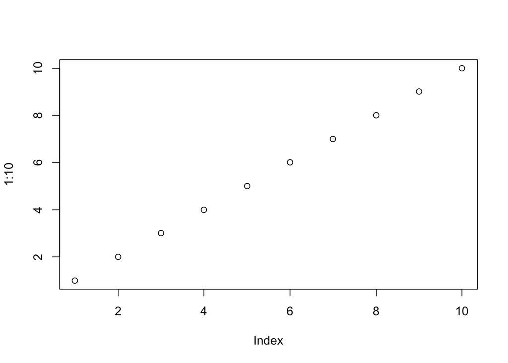

```r
plot(1:10)
```

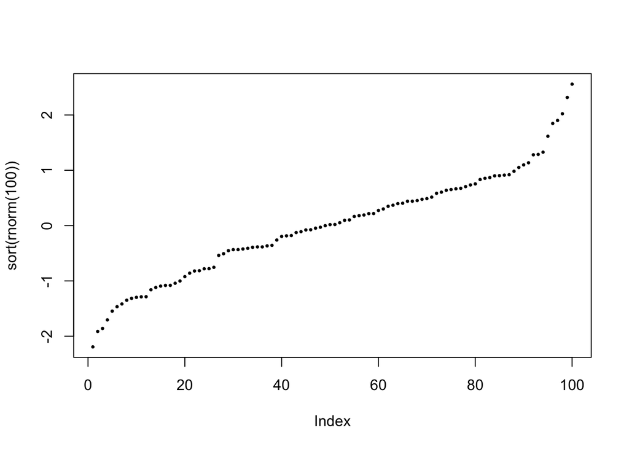

```r
plot(sort(rnorm(100)), pch=16, cex=0.5)                 # specifying point and size respectively
```

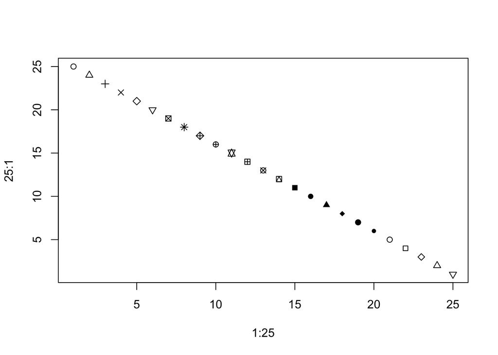

```r
plot(x=1:25, y=25:1, pch=1:25)                          # x & y inputs, and showing the available point symbols
```

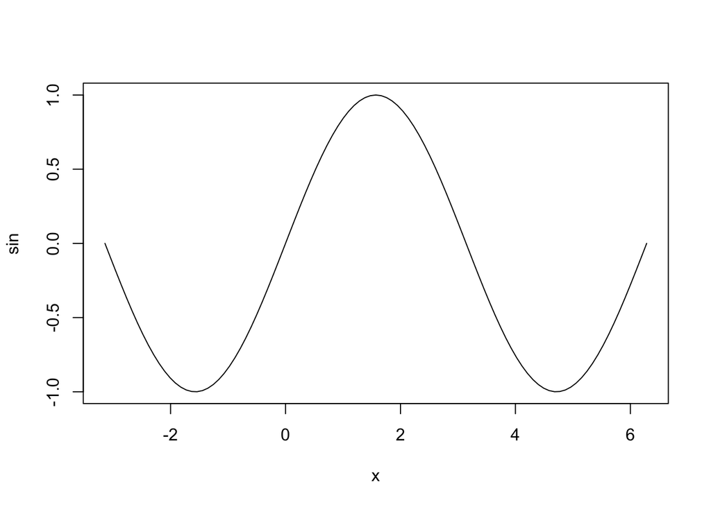

```r
plot(sin, -pi, 2*pi)
```

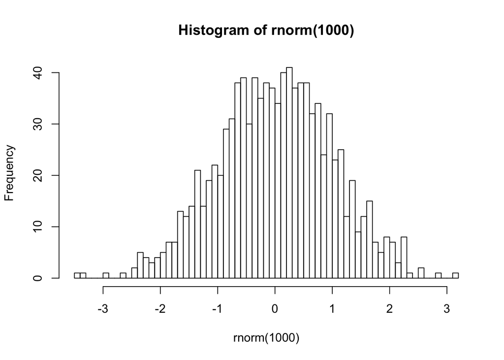

```r
hist(rnorm(1000), breaks=50)
```

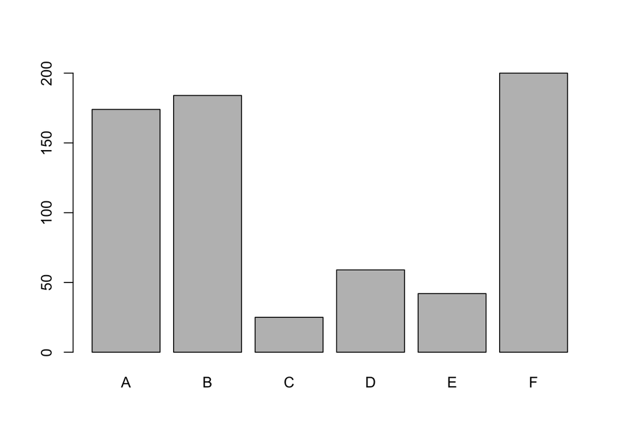

```r
barplot(sumInsects$sum, names.arg = sumInsects$group)
```

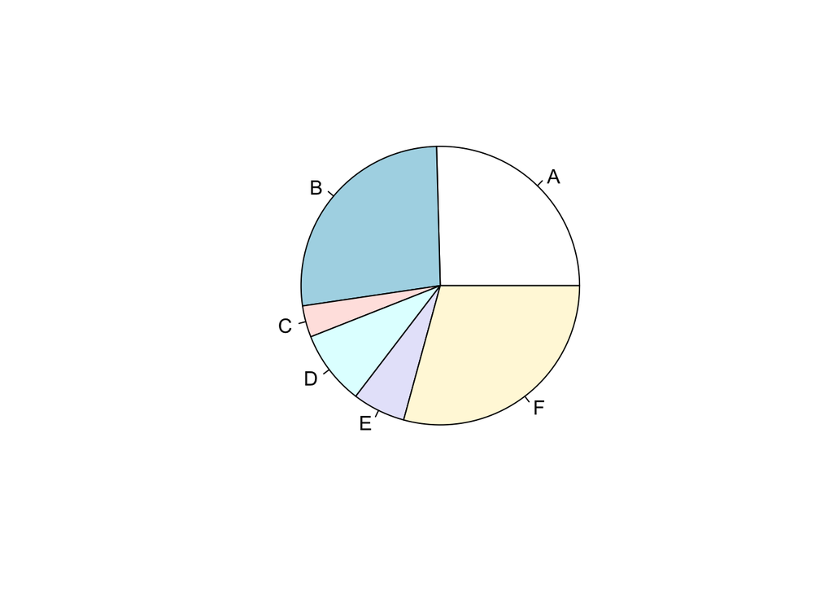

```r
pie(sumInsects$sum, labels = sumInsects$group)
```

- Rajouter des éléments dans un graphique

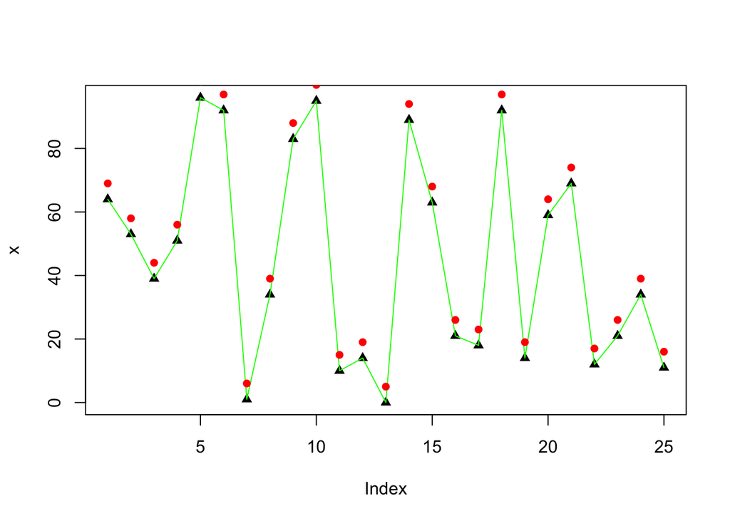

```r
x <- sample(0:100, 25, replace=TRUE)
plot(x, pch=17)
lines(x, col='#00FF00')
points(x+5, pch=16, col='red')
```

- Barplot

```r
sumWB <- aggregate(warpbreaks$breaks, by=list(warpbreaks$wool, warpbreaks$tension), FUN=mean)
names(sumWB) <- c('wool','tension','mean_breaks')
(data <- cbind(sumWB$mean_breaks[c(1,3,5)], sumWB$mean_breaks[c(2,4,6)]))
```

```
##          [,1]     [,2]
## [1,] 44.55556 28.22222
## [2,] 24.00000 33.50000
## [3,] 24.55556 18.77778
```

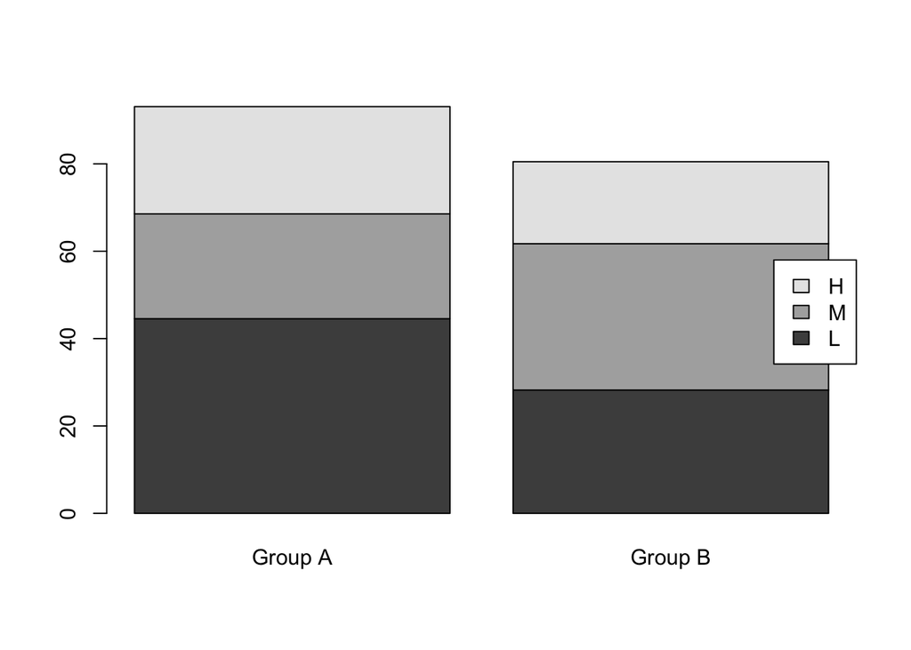

```r
barplot(data, names.arg=c('Group A','Group B'),
        legend.text=c('L','M','H'), args.legend = list(x = "right"))
```

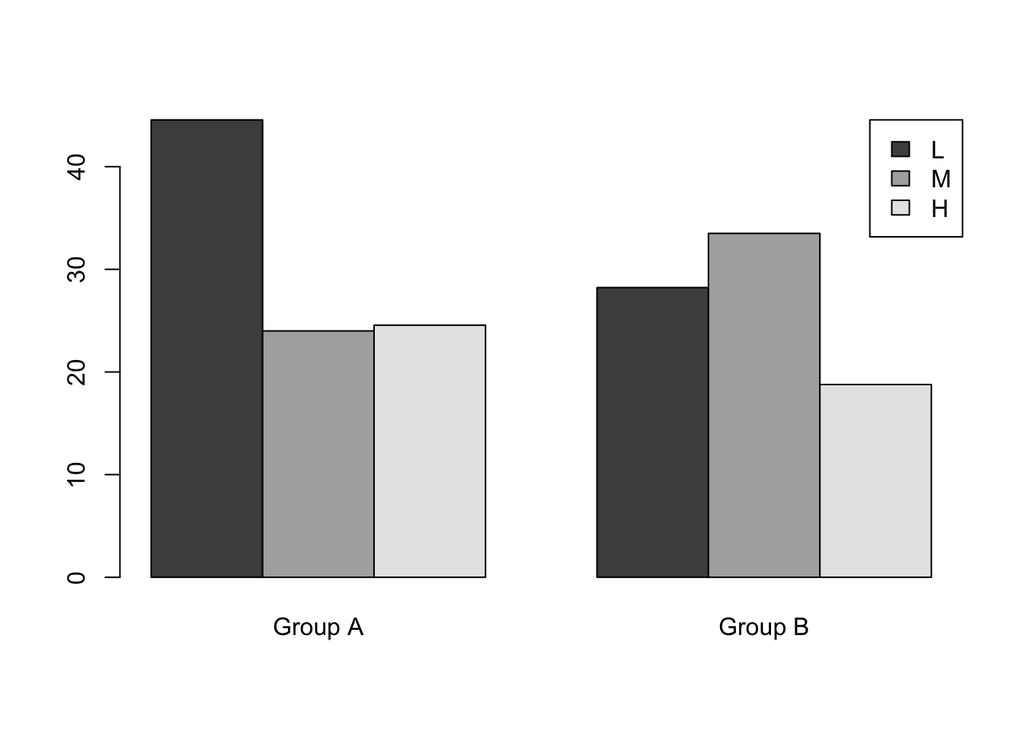

```r
barplot(data, names.arg=c('Group A','Group B'), beside=T,
        legend.text=c('L','M','H'), args.legend = list(x = "topright"))
```

- Utilisation de symboles

```r
(cities <- data.frame(city=c('London','Bristol','Manchester','Leeds'),
                      lon=c(-0.1,-2.6,-2.2,-1.5), lat=c(51.5,51.4,53.5,53.8), pop=c(8,1,2.7,0.8)))
```

| city | lon | lat | pop |
| --- | --- | --- | --- |
| London | -0.1 | 51.5 | 8.0 |
| Bristol | -2.6 | 51.4 | 1.0 |
| Manchester | -2.2 | 53.5 | 2.7 |
| Leeds | -1.5 | 53.8 | 0.8 |

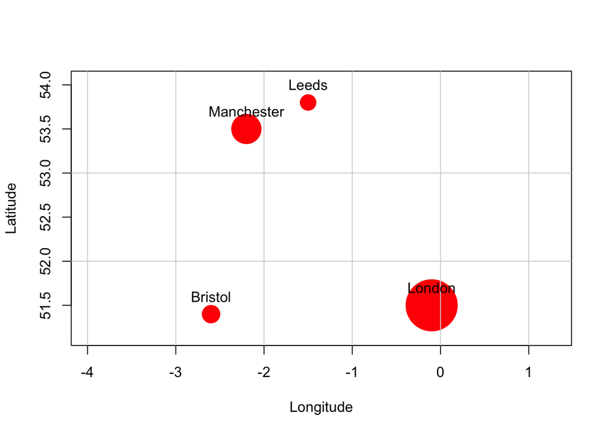

```r
symbols(x=cities$lon, y=cities$lat, circles=sqrt(cities$pop), inches=0.3,
        bg='red', fg=NULL, asp=T, xlab='Longitude', ylab='Latitude')
abline(h=(seq(51,53,1)), col="lightgray", lty=1)
abline(v=(seq(-4,1,1)), col="lightgray", lty=1)
text(x=cities$lon, y=cities$lat+0.2, labels=cities$city)
```

# 7 Utilisation de rmd

Rmarkdown permet de stocker le code R avec une structure de rapport.

Quelques remarques pratiques:

- Sauvegarder le code d’installations de packages dans un chunk avec `eval=FALSE`
- Regrouper le chargement de library dans un chunk au début du code
- Ne pas afficher des messages ou warnings en précisant: `message=FALSE` ou `warning=FALSE`